# Topic Modeling: News Coverage of Lay Use of AI Chatbots for Health

Zirong Li

2026-11-14

#——————————————— # Topic Modeling: pilot sample #———————————————

This notebook imports 806 Nexis Uni news articles (Pilot sample of U.S. news about AI and health, with my screening labels), keeps the 700-article random sample, and runs LDA topic modeling with the LADAL method, adapted from Rob Wells’s demo code: https://ladal.edu.au/tutorials/topic/topic.html

Load up the packages if you haven’t already….

```r
#  install.packages("here")
#  install.packages("tidytext")
#  install.packages("quanteda")
#  install.packages("tm")
#  install.packages("topicmodels")
#  install.packages("reshape2")
#  install.packages("ggplot2")
#  install.packages("wordcloud")
#  install.packages("pals")
#  install.packages("SnowballC")
#  install.packages("lda")
#  install.packages("ldatuning")
#  install.packages("kableExtra")
#  install.packages("DT")
#  install.packages("flextable")
#  install.packages("remotes")
#  remotes::install_github("rlesur/klippy")
# install.packages("rio")
# install.packages("readtext")
# install.packages("formattable")
#
# remotes::install_github("nikita-moor/ldatuning")
```

### Import Data

```r
# import 806 articles (Nexis Uni full text + screening labels)
articles <- read_csv(here::here("806_articles_fulltext.csv"))
# keep the 700-article probability sample
sample700 <- articles %>%
  filter(in700 == TRUE)

# subset the 40 relevant (focal) articles
relevant <- sample700 %>%
  filter(focal == TRUE)

# subset the 660 irrelevant articles
irrelevant <- sample700 %>%
  filter(focal == FALSE)

#quick check
nrow(sample700)    # should be 700
```

```
## [1] 700
```

```r
nrow(relevant)     # should be 40
```

```
## [1] 40
```

```r
nrow(irrelevant)   # should be 660
```

```
## [1] 660
```

```r
count(sample700, period, focal)
```

```
## # A tibble: 8 × 3
##   period focal     n
##   <chr>  <lgl> <int>
## 1 P1     FALSE    88
## 2 P1     TRUE      4
## 3 P2     FALSE   140
## 4 P2     TRUE      3
## 5 P3     FALSE   211
## 6 P3     TRUE     15
## 7 P4     FALSE   221
## 8 P4     TRUE     18
```

# Topic Modeling all 700 articles

### Process into corpus object

```r
textdata <- sample700 %>%
  select(doc_id, text, year, period, focal) %>%
  as.data.frame()
```

### Remove stopwords, clean corpus

```r
# 1. Standard stopwords plus common news words
english_stopwords <- c(stopwords("en"),
                       "said", "says", "also", "can", "will", "one", "new", "like", "just")

# 2. Build corpus
corpus <- Corpus(DataframeSource(textdata))

# 3. Clean in correct sequence
processedCorpus <- tm_map(corpus, content_transformer(tolower))
processedCorpus <- tm_map(processedCorpus, removePunctuation, preserve_intra_word_dashes = TRUE)
processedCorpus <- tm_map(processedCorpus, removeNumbers)


# Remove stopwords BEFORE stemming
processedCorpus <- tm_map(processedCorpus, removeWords, english_stopwords)

# Stem documents after removing stopwords
processedCorpus <- tm_map(processedCorpus, stemDocument, language = "en")
processedCorpus <- tm_map(processedCorpus, stripWhitespace)
```

```r
#DTM: rows correspond to the documents in the corpus. Columns correspond to the terms in the documents. Cells correspond to the weights of the terms. (Girder)
# compute document term matrix with terms >= minimumFrequency
minimumFrequency <- 5
DTM <- DocumentTermMatrix(processedCorpus, control = list(bounds = list(global = c(minimumFrequency, Inf))))

# have a look at the number of documents and terms in the matrix
dim(DTM)
```

```
## [1]  700 5285
```

```r
# due to vocabulary pruning, we have empty rows in our DTM
# LDA does not like this. So we remove those docs from the
# DTM and the metadata
sel_idx <- slam::row_sums(DTM) > 0
DTM <- DTM[sel_idx, ]
textdata <- textdata[sel_idx, ]
dim(DTM)
```

```
## [1]  699 5285
```

## Topic proportions over time

```r
# append period labels for aggregation (in time order)
textdata$period_label <- factor(textdata$period,
                                levels = c("P1", "P2", "P3", "P4"),
                                labels = c("2022.12-2023", "2024", "2025", "2026.1-2026.9"))
```

Articles per period

```r
articles_periods <- textdata %>%
  distinct(doc_id, .keep_all = TRUE) %>%
  count(period_label) %>%
  mutate(pct_total = (n/sum(n))) %>%
  mutate(pct_total = formattable::percent(pct_total)) %>%
  arrange(desc(period_label))

articles_periods %>%
  kbl(caption = "Pilot Sample Articles by Period (n=699, 11/14/2026)", font_size = 30) %>%
  kable_classic(full_width = F, html_font = "Cambria") %>%
  column_spec(1, bold = T, border_right = T) %>%
  column_spec(2, width = "5em") %>%
  column_spec(3, width = "5em", background = "yellow")
```

Pilot Sample Articles by Period (n=699, 11/14/2026)

| period_label | n | pct_total |
| --- | --- | --- |
| 2026.1-2026.9 | 238 | 34.05% |
| 2025 | 226 | 32.33% |
| 2024 | 143 | 20.46% |
| 2022.12-2023 | 92 | 13.16% |

```r
#Fact check 699 articles
#sum(articles_periods$n) # yes, it is 699
```

```r
# number of topics
K <- 6
# set random number generator seed
set.seed(9161)
#Latent Dirichlet Allocation, LDA
topicModel2 <- LDA(DTM, K, method="Gibbs", control=list(iter = 500, verbose = 25, alpha = 0.2))
```

```
## K = 6; V = 5285; M = 699
## Sampling 500 iterations!
## Iteration 25 ...
## Iteration 50 ...
## Iteration 75 ...
## Iteration 100 ...
## Iteration 125 ...
## Iteration 150 ...
## Iteration 175 ...
## Iteration 200 ...
## Iteration 225 ...
## Iteration 250 ...
## Iteration 275 ...
## Iteration 300 ...
## Iteration 325 ...
## Iteration 350 ...
## Iteration 375 ...
## Iteration 400 ...
## Iteration 425 ...
## Iteration 450 ...
## Iteration 475 ...
## Iteration 500 ...
## Gibbs sampling completed!
```

```r
tmResult <- posterior(topicModel2)
theta <- tmResult$topics
beta <- tmResult$terms
topicNames <- apply(terms(topicModel2, 10), 2, paste, collapse = " ")  # reset topicnames
```

### Mean topic proportions per period

```r
# Step 1: Check dimensions
n_theta <- nrow(theta)
n_textdata <- length(textdata$period_label)

cat("Number of rows in theta: ", n_theta, "\n")
```

```
## Number of rows in theta:  699
```

```r
cat("Number of documents in textdata: ", n_textdata, "\n")
```

```
## Number of documents in textdata:  699
```

```r
# Check if textdata contains all the documents in theta
common_ids <- intersect(rownames(theta), textdata$doc_id)

# Filter textdata to include only the documents present in theta
textdata_filtered <- textdata[textdata$doc_id %in% common_ids, ]

# Check dimensions after filtering
n_textdata_filtered <- nrow(textdata_filtered)
cat("Number of documents in filtered textdata: ", n_textdata_filtered, "\n")
```

```
## Number of documents in filtered textdata:  699
```

```r
# Ensure the lengths match now
if (n_theta != n_textdata_filtered) {
  stop("The number of rows in 'theta' still does not match the length of 'textdata_filtered$period_label'.")
}

# Align rownames of theta with filtered textdata
theta_aligned <- theta[rownames(theta) %in% textdata_filtered$doc_id, ]

# Optional: Verify the order of documents
if (!all(rownames(theta_aligned) == textdata_filtered$doc_id)) {
  # If the order doesn't match, reorder one to match the other
  textdata_filtered <- textdata_filtered[match(rownames(theta_aligned), textdata_filtered$doc_id), ]
}

# Ensure they are now aligned and can be combined
if (!all(rownames(theta_aligned) == textdata_filtered$doc_id)) {
  stop("The document IDs still do not match. Please check the data alignment.")
}

# Step 2: Combine data
topic_data <- data.frame(theta_aligned, period_label = textdata_filtered$period_label)

# Step 3: Aggregate data
topic_proportion_per_period <- aggregate(. ~ period_label, data = topic_data, FUN = mean)

# set topic names to aggregated columns
colnames(topic_proportion_per_period)[2:(K+1)] <- topicNames
# reshape data frame
vizDataFrame <- melt(topic_proportion_per_period, id.vars = "period_label")
```

#Examine topic names

```r
#enframe(): Converts a named list into a dataframe.
topics <- enframe(topicNames, name = "number", value = "text") %>%
  unnest(cols = c(text))

topics
```

```
## # A tibble: 6 × 2
##   number  text
##   <chr>   <chr>
## 1 Topic 1 compani year busi data market industri tech billion product invest
## 2 Topic 2 health use patient medic care research data system doctor help
## 3 Topic 3 use student chatgpt chatbot peopl human question inform openai school
## 4 Topic 4 time get make work peopl thing look year want way
## 5 Topic 5 googl use featur app model search user appl watch imag
## 6 Topic 6 state “ trump — american ’s presid center public includ
```

### Review the topics and determine a 1-2 word label after reading the source documents.

The function below lists the 20 articles that load most on a topic, with headline, outlet, and whether the article is relevant (focal = TRUE).

```r
top_articles_for <- function(topic_n) {
  as.data.frame(theta) %>%
    rownames_to_column(var = "doc_id") %>%
    rename(topic = all_of(as.character(topic_n))) %>%
    top_n(20, topic) %>%
    arrange(desc(topic)) %>%
    left_join(sample700 %>% select(doc_id, focal, headline, outlet), by = "doc_id") %>%
    select(doc_id, focal, headline, outlet, topic)
}
```

#### Topic 1

```r
top_articles_for(1)
```

```
##    doc_id focal
## 1  P2-112 FALSE
## 2  P4-220 FALSE
## 3  P3-033 FALSE
## 4  P4-068 FALSE
## 5  P4-063 FALSE
## 6  P4-189 FALSE
## 7  P4-012 FALSE
## 8  P4-085 FALSE
## 9  P2-049 FALSE
## 10 P2-136 FALSE
## 11 P3-065 FALSE
## 12 P3-041 FALSE
## 13 P4-041 FALSE
## 14 P3-005 FALSE
```

[output cut: 48 more lines]

#### Topic 2

```r
top_articles_for(2)
```

```
##    doc_id focal
## 1  P3-225 FALSE
## 2  P2-068 FALSE
## 3  P1-057 FALSE
## 4  P4-201 FALSE
## 5  P1-080 FALSE
## 6  P4-066 FALSE
## 7  P2-119 FALSE
## 8  P3-098 FALSE
## 9  P3-095 FALSE
## 10 P4-202 FALSE
## 11 P3-054 FALSE
## 12 P1-093 FALSE
## 13 P3-211 FALSE
## 14 P4-084 FALSE
```

[output cut: 48 more lines]

#### Topic 3

```r
top_articles_for(3)
```

```
##    doc_id focal
## 1  P3-191  TRUE
## 2  P4-147 FALSE
## 3  P4-119 FALSE
## 4  P3-234 FALSE
## 5  P2-124 FALSE
## 6  P4-128 FALSE
## 7  P3-044 FALSE
## 8  P1-050 FALSE
## 9  P3-220  TRUE
## 10 P3-003  TRUE
## 11 P3-008  TRUE
## 12 P4-096 FALSE
## 13 P3-207 FALSE
## 14 P4-229 FALSE
```

[output cut: 48 more lines]

#### Topic 4

```r
top_articles_for(4)
```

```
##    doc_id focal
## 1  P4-097 FALSE
## 2  P1-003 FALSE
## 3  P1-042 FALSE
## 4  P2-131 FALSE
## 5  P4-142 FALSE
## 6  P4-246  TRUE
## 7  P3-093 FALSE
## 8  P2-153 FALSE
## 9  P3-187 FALSE
## 10 P3-149 FALSE
## 11 P1-038 FALSE
## 12 P3-039 FALSE
## 13 P2-100 FALSE
## 14 P3-160 FALSE
```

[output cut: 48 more lines]

#### Topic 5

```r
top_articles_for(5)
```

```
##    doc_id focal
## 1  P3-202 FALSE
## 2  P1-070 FALSE
## 3  P4-024 FALSE
## 4  P4-110 FALSE
## 5  P2-059 FALSE
## 6  P1-056 FALSE
## 7  P3-193 FALSE
## 8  P3-204 FALSE
## 9  P3-020 FALSE
## 10 P2-109 FALSE
## 11 P2-127 FALSE
## 12 P1-024 FALSE
## 13 P4-188 FALSE
## 14 P3-231 FALSE
```

[output cut: 48 more lines]

#### Topic 6

```r
top_articles_for(6)
```

```
##    doc_id focal
## 1  P3-153 FALSE
## 2  P4-045 FALSE
## 3  P3-059 FALSE
## 4  P4-216 FALSE
## 5  P3-217 FALSE
## 6  P2-022 FALSE
## 7  P3-091 FALSE
## 8  P3-116 FALSE
## 9  P4-164 FALSE
## 10 P3-078 FALSE
## 11 P1-061 FALSE
## 12 P4-038 FALSE
## 13 P4-182 FALSE
## 14 P3-010 FALSE
```

[output cut: 48 more lines]

Topic 1 business_markets: compani year busi data market industri tech billion product invest  
Topic 2 medical_ai: health use patient medic care research data system doctor help  
Topic 3 chatbot_use_risks: use student chatgpt chatbot peopl human question inform openai school  
Topic 4 lifestyle_entertainment: time get make work peopl thing look year want way  
Topic 5 tech_products: googl use featur app model search user appl watch imag  
Topic 6 politics_public_affairs: state trump american presid center public includ

```r
#add categories
# one label per topic, in topic order (edit after reading the articles)
topic_labels <- c("business_markets", "medical_ai", "chatbot_use_risks",
                  "lifestyle_entertainment", "tech_products", "politics_public_affairs")

vizDataFrame <- vizDataFrame %>%
  mutate(category = case_when(
    variable == topicNames[1] ~ topic_labels[1],
    variable == topicNames[2] ~ topic_labels[2],
    variable == topicNames[3] ~ topic_labels[3],
    variable == topicNames[4] ~ topic_labels[4],
    variable == topicNames[5] ~ topic_labels[5],
    variable == topicNames[6] ~ topic_labels[6]
    ))
```

# Relevant and Irrelevant Topics

Mean topic proportion in relevant articles (lay use of GenAI chatbots for health is the central subject) and irrelevant articles. A topic with a much higher share in relevant articles is a relevant topic.

```r
# number of relevant and irrelevant articles in the model
table(textdata$focal)
```

```
##
## FALSE  TRUE
##   659    40
```

```r
# mean topic proportion by group
topic_by_focal <- aggregate(theta, by = list(focal = textdata$focal), mean)
colnames(topic_by_focal)[2:(K+1)] <- topic_labels

# table: one row per topic
relevance_table <- topic_by_focal %>%
  pivot_longer(-focal, names_to = "topic", values_to = "mean_proportion") %>%
  mutate(focal = if_else(focal, "relevant", "irrelevant")) %>%
  pivot_wider(names_from = focal, values_from = mean_proportion) %>%
  mutate(difference = relevant - irrelevant) %>%
  arrange(desc(difference))

relevance_table %>%
  kbl(caption = "Mean Topic Proportion in Relevant vs. Irrelevant Articles", digits = 3) %>%
  kable_classic(full_width = F, html_font = "Cambria")
```

Mean Topic Proportion in Relevant vs. Irrelevant Articles

| topic | irrelevant | relevant | difference |
| --- | --- | --- | --- |
| chatbot_use_risks | 0.172 | 0.420 | 0.249 |
| medical_ai | 0.154 | 0.224 | 0.070 |
| lifestyle_entertainment | 0.204 | 0.182 | -0.021 |
| tech_products | 0.138 | 0.093 | -0.045 |
| politics_public_affairs | 0.142 | 0.046 | -0.096 |
| business_markets | 0.191 | 0.035 | -0.156 |

#Figure: Relevant vs. irrelevant topics

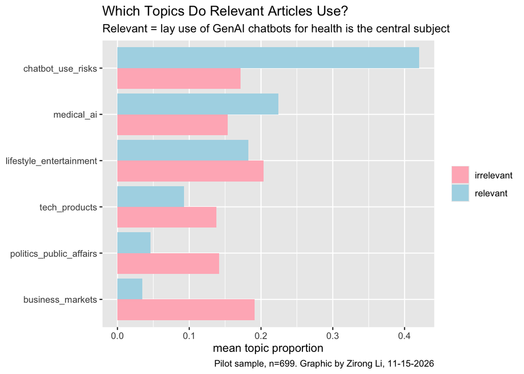

```r
relevance_table %>%
  pivot_longer(c(relevant, irrelevant), names_to = "group", values_to = "mean_proportion") %>%
  mutate(topic = fct_reorder(topic, difference)) %>%
  ggplot(aes(x = mean_proportion, y = topic, fill = group)) +
  geom_col(position = "dodge") +
  scale_fill_manual(values = c("relevant" = "lightblue", "irrelevant" = "lightpink"), name = NULL) +
  labs(title = "Which Topics Do Relevant Articles Use?",
       subtitle = "Relevant = lay use of GenAI chatbots for health is the central subject",
       x = "mean topic proportion", y = NULL,
       caption = "Pilot sample, n=699. Graphic by Zirong Li, 11-15-2026")
```

#Figure: Topics in AI and health news by period

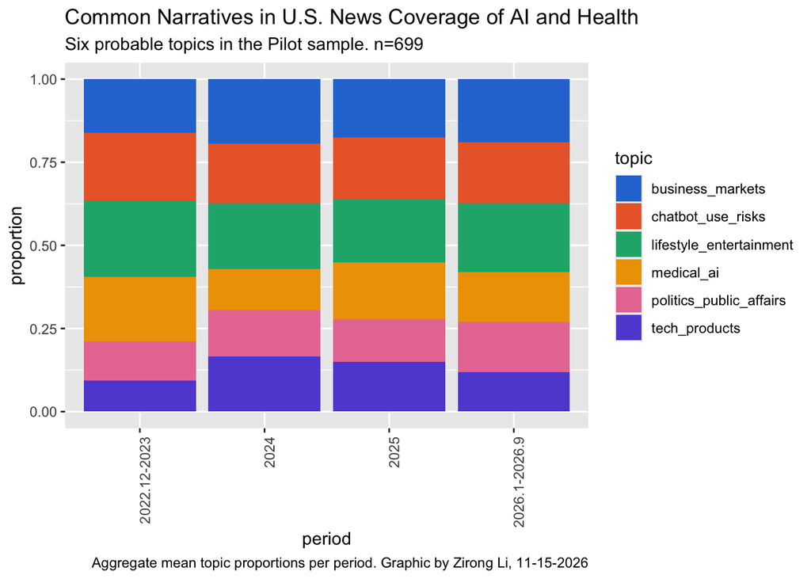

```r
# plot topic proportions per period as bar plot
ggplot(vizDataFrame, aes(x=period_label, y=value, fill=category)) +
  geom_bar(stat = "identity") + ylab("proportion") + xlab("period") +
  theme(axis.text.x = element_text(angle = 90, hjust = 1)) +
  scale_fill_manual(values=c("#2a78d6",
                             "#eb6834",
                             "#1baf7a",
                             "#eda100",
                             "#e87ba4",
                             "#6250d6"),
                    name = "topic") +
  labs(title = "Common Narratives in U.S. News Coverage of AI and Health",
       subtitle = "Six probable topics in the Pilot sample. n=699",
       caption = "Aggregate mean topic proportions per period. Graphic by Zirong Li, 11-15-2026")
```

# Summary

I ran an LDA topic model (K = 6) on the 699 articles in my Pilot sample, drawn from a broad AI-and-health search in Nexis Uni. Only 40 of them are relevant to my project after screening: lay people’s use of GenAI chatbots for health is the central subject. I compared each topic’s average share in the relevant and irrelevant articles.

One topic is clearly relevant. Chatbot use and risks makes up 42% of the relevant articles but 17% of the others. Its top articles cover ChatGPT and teen mental health, a California law on companion chatbots, and lawsuits against OpenAI, the same harm stories I found when reading the full articles. Medical AI is partly relevant (22% vs. 15%), but it covers clinical tools for doctors, not lay users. Four topics are irrelevant: business and markets, tech products, politics, and lifestyle and entertainment (horoscopes, recipes, reviews), most of which never mention generative AI.

The benefit is a quick map of a large sample. The model shows where the noise in my search comes from, which will help me revise the search string before collecting the full corpus. The shortfalls are clear. The chatbot topic mixes health stories with campus stories about AI and cheating as an example, so it does not show the rise in relevant coverage from 2023 to 2026 that I found by reading. Some relevant articles fall into unrelated topics. Topics are word patterns, not frames. They cannot show the roles, attribution, or advice my research questions ask about, so I still need the codebook.